# Machine learning project

Max Reimerson

3 June, 2017

# Executive summary

This report looks at the data from training measurements using devices like Fitbit etc. The aim is to use the data from the fitbit to predict the what type of excecise is performend and how well it was done. All the different excecises are encoded as A,B,C… etc, and here I build a model to predict them given the input data.

# Exploratory analysis

```r
training.full <- read.csv('https://d396qusza40orc.cloudfront.net/predmachlearn/pml-training.csv')
```

```r
dim(training.full)
```

```
## [1] 19622   160
```

## Data cleanup and pre-processing

There are 160 columns worth of data which makes it difficult to work with. The data is structured into windows of observation and each window starts with a summarization of the other observations. Since we don’t have the whole window in the out of sample data the window information and the summarization is not useful. So first I will filter out all the summary rows:

```r
# Filter out new_window = 'yes' because it seems to be some summary row and it doesn't exist in the validation set so we can't use this anyway
training.flt <- training.full[training.full$new_window == 'no',]
```

Secondly, most of the columns are summarizing statistics about the window, which will only be populated for the summarization row.

Here is what the 20 first columns look like. Most of them are empty:

```
##   X user_name raw_timestamp_part_1 raw_timestamp_part_2   cvtd_timestamp
## 1 1  carlitos           1323084231               788290 05/12/2011 11:23
## 2 2  carlitos           1323084231               808298 05/12/2011 11:23
## 3 3  carlitos           1323084231               820366 05/12/2011 11:23
##   new_window num_window roll_belt pitch_belt yaw_belt total_accel_belt
## 1         no         11      1.41       8.07    -94.4                3
## 2         no         11      1.41       8.07    -94.4                3
## 3         no         11      1.42       8.07    -94.4                3
##   kurtosis_roll_belt kurtosis_picth_belt kurtosis_yaw_belt
## 1
## 2
## 3
##   skewness_roll_belt skewness_roll_belt.1 skewness_yaw_belt max_roll_belt
## 1                                                                      NA
## 2                                                                      NA
## 3                                                                      NA
##   max_picth_belt max_yaw_belt
## 1             NA
## 2             NA
## 3             NA
```

So we can remove all these columns.

```r
# Because we filtered out all summary rows the stats columns are now only NA, so remove those
training.flt <- training.flt[,-grep("^avg|skewness|max|kurtosis|min|stddev|var|amplitude", colnames(training.flt))]
```

Because we’re not using the “window” anymore the new_window variable is now redudundant. The timestamps, X and window_num as only sequential variables, which will have a high correlation with the outcome because the outcome is done in sequence, you can see the plot.

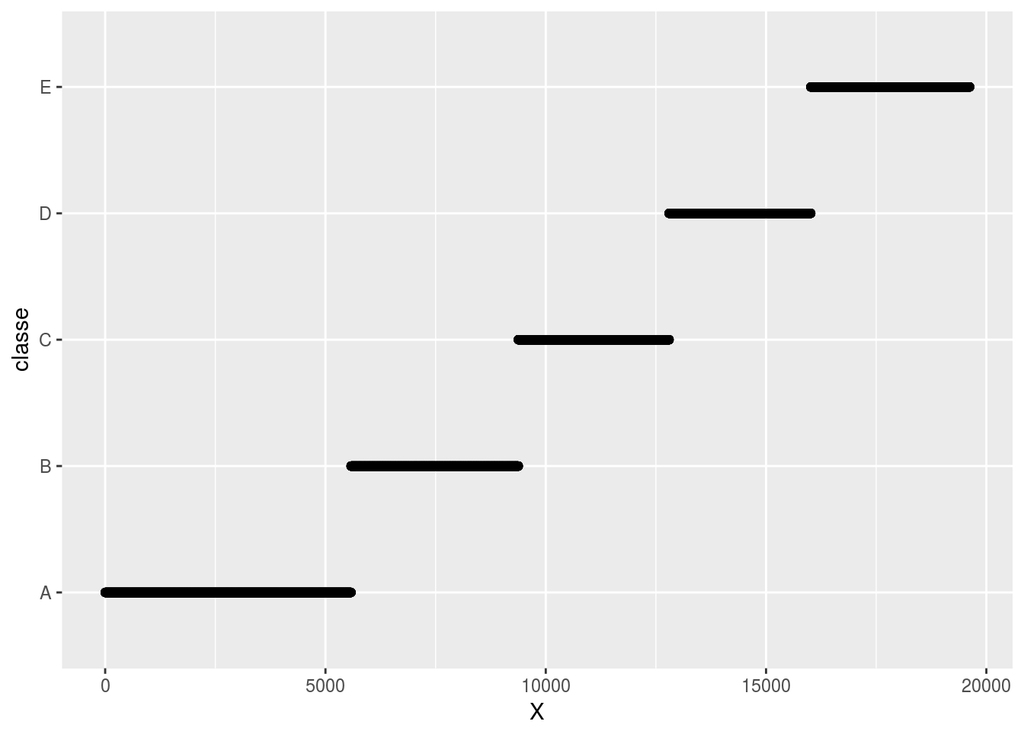

This will mess up prediction as its not reasonable to expect this in an out of sample dataset

Also to make the analysis meaningful we want to exclude the use who does this as that won’t scale if the model needs to be fitted for each user

```r
training.clean <- training.flt[,-grep("X|window|timestamp|user_name", colnames(training.flt))]
```

Now we have a clean dataset to perform predictions on, which only has nummeric inputs and the outcome variable “classe”

```r
dim(training.clean)
```

```
## [1] 19216    53
```

```r
head(training.clean, n=3)
```

```
##   roll_belt pitch_belt yaw_belt total_accel_belt gyros_belt_x gyros_belt_y
## 1      1.41       8.07    -94.4                3         0.00            0
## 2      1.41       8.07    -94.4                3         0.02            0
## 3      1.42       8.07    -94.4                3         0.00            0
##   gyros_belt_z accel_belt_x accel_belt_y accel_belt_z magnet_belt_x
## 1        -0.02          -21            4           22            -3
## 2        -0.02          -22            4           22            -7
## 3        -0.02          -20            5           23            -2
##   magnet_belt_y magnet_belt_z roll_arm pitch_arm yaw_arm total_accel_arm
## 1           599          -313     -128      22.5    -161              34
## 2           608          -311     -128      22.5    -161              34
## 3           600          -305     -128      22.5    -161              34
##   gyros_arm_x gyros_arm_y gyros_arm_z accel_arm_x accel_arm_y accel_arm_z
## 1        0.00        0.00       -0.02        -288         109        -123
## 2        0.02       -0.02       -0.02        -290         110        -125
```

[output cut: 33 more lines]

## Cross validation

Divide the dataset up into a training, testing and validation dataset so that we can do cross validation. 60% for training data 15% for testing to determine the best model 25% for validation - used to estimate the out of sample error

```r
inTrain <- createDataPartition(training.clean$classe, p = 0.60, list = FALSE)

training <- training.clean[inTrain,]

testing.all <- training.clean[-inTrain,]
inValidation <- createDataPartition(testing.all$classe, p = 0.625, list = FALSE)

testing <- testing.all[-inValidation,]
testing.validation <- testing.all[inValidation,]

## Also define a function for testing the models
testModel <-function(mod) {
  confusionMatrix(table(testing$classe, predict(mod, newdata = testing)))
}

validateModel <-function(mod) {
  confusionMatrix(table(testing.validation$classe, predict(mod, newdata = testing.validation)))
}
```

## Pre processing

The next thing to do is to try princinple component analysis to reduce the number of variables.

```r
testing.x <- testing[-ncol(testing)]
training.x <- training[-ncol(training)]
# PCA
training.pr <- prcomp(training.x)
# Get the components for 95 % of the variance
preProc.pca <- preProcess(training.x, method="pca", thresh = .95)
trainPC <- predict(preProc.pca, training.x)
trainPC$classe <- training$classe
```

Now we have a smaller set of variables explaining 95% of the variance in the original dataset

```r
dim(trainPC)
```

```
## [1] 11532    26
```

# Model selection

Because I try to evaluate a multi-class prediction I can’t use linear models or even any models based on binomial outcomes like glm or adaboost as these expects only 2 classes.

I will mainly stick to tree based models.

## Prediction trees

Now first try to predict the outcome using a prediction tree

```r
set.seed(12345)
model.rpart <- train(classe ~ ., data=training,method="rpart")
testModel(model.rpart)
```

```
## Confusion Matrix and Statistics
##
##
##       A   B   C   D   E
##   A 736  17  67   0   0
##   B 249 171 137   0   0
##   C 217  10 275   0   0
##   D 202 100 169   0   0
##   E  68  70 145   0 246
##
## Overall Statistics
##
##                Accuracy : 0.496
##                  95% CI : (0.4776, 0.5144)
##     No Information Rate : 0.5113
##     P-Value [Acc > NIR] : 0.9514
##
##                   Kappa : 0.342
##  Mcnemar's Test P-Value : NA
##
## Statistics by Class:
##
##                      Class: A Class: B Class: C Class: D Class: E
## Sensitivity            0.5000   0.4647  0.34678       NA  1.00000
## Specificity            0.9403   0.8463  0.89118   0.8364  0.89252
## Pos Pred Value         0.8976   0.3070  0.54781       NA  0.46503
## Neg Pred Value         0.6425   0.9152  0.78208       NA  1.00000
## Prevalence             0.5113   0.1278  0.27544   0.0000  0.08545
## Detection Rate         0.2556   0.0594  0.09552   0.0000  0.08545
## Detection Prevalence   0.2848   0.1935  0.17437   0.1636  0.18374
## Balanced Accuracy      0.7201   0.6555  0.61898       NA  0.94626
```

Pretty low accuracy, we should be able to do better.

Also define another testing function that applies the princinple components from the trainingset to the testing data and evaluates models based on that

```r
testModel.pca <-function(mod, preProc.pca) {
  testPC <- predict(preProc.pca, testing.x)
  confusionMatrix(table(testing$classe, predict(mod, newdata = testPC)))
}
```

First try a normal prediction tree based on the princinple components

```r
set.seed(12345)
model.pca.rpart <- train(classe ~ .,method="rpart", data=trainPC)
```

```r
testModel.pca(model.pca.rpart, preProc.pca)
```

```
## Confusion Matrix and Statistics
##
##
##       A   B   C   D   E
##   A 741   0   0  61  18
##   B 398   0   0  91  68
##   C 469   0   0  11  22
##   D 240   0   0 189  42
##   E 311   0   0  64 154
##
## Overall Statistics
##
##                Accuracy : 0.3765
##                  95% CI : (0.3588, 0.3945)
##     No Information Rate : 0.7499
##     P-Value [Acc > NIR] : 1
##
##                   Kappa : 0.1613
##  Mcnemar's Test P-Value : NA
##
## Statistics by Class:
##
##                      Class: A Class: B Class: C Class: D Class: E
## Sensitivity            0.3432       NA       NA  0.45433  0.50658
## Specificity            0.8903   0.8065   0.8256  0.88551  0.85437
## Pos Pred Value         0.9037       NA       NA  0.40127  0.29112
## Neg Pred Value         0.3113       NA       NA  0.90573  0.93617
## Prevalence             0.7499   0.0000   0.0000  0.14449  0.10559
## Detection Rate         0.2574   0.0000   0.0000  0.06565  0.05349
## Detection Prevalence   0.2848   0.1935   0.1744  0.16360  0.18374
## Balanced Accuracy      0.6167       NA       NA  0.66992  0.68047
```

Accuracy is even worse.

## Bagging

Next thing to try is a bagged model, I use a bagged tree.

```r
set.seed(12345)
model.pca.treebag <- train(classe ~ .,method="treebag", data=trainPC)
testModel.pca(model.pca.treebag, preProc.pca)
```

```
## Confusion Matrix and Statistics
##
##
##       A   B   C   D   E
##   A 795  12   6   6   1
##   B  15 507  26   3   6
##   C   5  11 477   8   1
##   D   3   1  28 435   4
##   E   1   7   4   4 513
##
## Overall Statistics
##
##                Accuracy : 0.9472
##                  95% CI : (0.9384, 0.9551)
##     No Information Rate : 0.2845
##     P-Value [Acc > NIR] : <2e-16
##
##                   Kappa : 0.9332
##  Mcnemar's Test P-Value : 0.0179
##
## Statistics by Class:
##
##                      Class: A Class: B Class: C Class: D Class: E
## Sensitivity            0.9707   0.9424   0.8817   0.9539   0.9771
## Specificity            0.9879   0.9786   0.9893   0.9851   0.9932
## Pos Pred Value         0.9695   0.9102   0.9502   0.9236   0.9698
## Neg Pred Value         0.9883   0.9866   0.9731   0.9913   0.9949
## Prevalence             0.2845   0.1869   0.1879   0.1584   0.1824
## Detection Rate         0.2761   0.1761   0.1657   0.1511   0.1782
## Detection Prevalence   0.2848   0.1935   0.1744   0.1636   0.1837
## Balanced Accuracy      0.9793   0.9605   0.9355   0.9695   0.9852
```

Accuracy is a lot better. Let’s try it without the principal components.

```r
set.seed(12345)

model.treebag <- train(classe ~ ., data=training,method="treebag")
```

```r
testModel(model.treebag)
```

```
## Confusion Matrix and Statistics
##
##
##       A   B   C   D   E
##   A 811   6   2   1   0
##   B   6 536  13   1   1
##   C   1   7 493   0   1
##   D   0   3   8 458   2
##   E   0   4   2   1 522
##
## Overall Statistics
##
##                Accuracy : 0.9795
##                  95% CI : (0.9736, 0.9844)
##     No Information Rate : 0.2841
##     P-Value [Acc > NIR] : < 2.2e-16
##
##                   Kappa : 0.9741
##  Mcnemar's Test P-Value : NA
##
## Statistics by Class:
##
##                      Class: A Class: B Class: C Class: D Class: E
## Sensitivity            0.9914   0.9640   0.9517   0.9935   0.9924
## Specificity            0.9956   0.9910   0.9962   0.9946   0.9970
## Pos Pred Value         0.9890   0.9623   0.9821   0.9724   0.9868
## Neg Pred Value         0.9966   0.9914   0.9895   0.9988   0.9983
## Prevalence             0.2841   0.1931   0.1799   0.1601   0.1827
## Detection Rate         0.2817   0.1862   0.1712   0.1591   0.1813
## Detection Prevalence   0.2848   0.1935   0.1744   0.1636   0.1837
## Balanced Accuracy      0.9935   0.9775   0.9740   0.9941   0.9947
```

Accuracy is pretty good.

## Boosting

Try gradient boosting.

```r
set.seed(12345)

model.gbm <- train(classe ~ ., data=training,method="gbm")
testModel(model.gbm)
```

```
## Confusion Matrix and Statistics
##
##
##       A   B   C   D   E
##   A 799  16   3   2   0
##   B  20 510  25   0   2
##   C   0  19 481   2   0
##   D   0   2  14 451   4
##   E   1   4   0   7 517
##
## Overall Statistics
##
##                Accuracy : 0.958
##                  95% CI : (0.95, 0.965)
##     No Information Rate : 0.2848
##     P-Value [Acc > NIR] : < 2.2e-16
##
##                   Kappa : 0.9468
##  Mcnemar's Test P-Value : NA
##
## Statistics by Class:
##
##                      Class: A Class: B Class: C Class: D Class: E
## Sensitivity            0.9744   0.9256   0.9197   0.9762   0.9885
## Specificity            0.9898   0.9798   0.9911   0.9917   0.9949
## Pos Pred Value         0.9744   0.9156   0.9582   0.9575   0.9773
## Neg Pred Value         0.9898   0.9823   0.9823   0.9954   0.9974
## Prevalence             0.2848   0.1914   0.1817   0.1605   0.1817
## Detection Rate         0.2775   0.1771   0.1671   0.1567   0.1796
## Detection Prevalence   0.2848   0.1935   0.1744   0.1636   0.1837
## Balanced Accuracy      0.9821   0.9527   0.9554   0.9840   0.9917
```

Accuracy is pretty good, but not as good as the bagged tree.

## Random Forest

Finally try a random forest.

```r
set.seed(12345)
model.rf <- train(classe ~ ., data=training,method="rf")
testModel(model.rf)
```

```
## Confusion Matrix and Statistics
##
##
##       A   B   C   D   E
##   A 819   1   0   0   0
##   B   4 543  10   0   0
##   C   0   5 497   0   0
##   D   0   0  12 459   0
##   E   0   0   0   0 529
##
## Overall Statistics
##
##                Accuracy : 0.9889
##                  95% CI : (0.9843, 0.9924)
##     No Information Rate : 0.2859
##     P-Value [Acc > NIR] : < 2.2e-16
##
##                   Kappa : 0.9859
##  Mcnemar's Test P-Value : NA
##
## Statistics by Class:
##
##                      Class: A Class: B Class: C Class: D Class: E
## Sensitivity            0.9951   0.9891   0.9576   1.0000   1.0000
## Specificity            0.9995   0.9940   0.9979   0.9950   1.0000
## Pos Pred Value         0.9988   0.9749   0.9900   0.9745   1.0000
## Neg Pred Value         0.9981   0.9974   0.9907   1.0000   1.0000
## Prevalence             0.2859   0.1907   0.1803   0.1594   0.1837
## Detection Rate         0.2845   0.1886   0.1726   0.1594   0.1837
## Detection Prevalence   0.2848   0.1935   0.1744   0.1636   0.1837
## Balanced Accuracy      0.9973   0.9915   0.9777   0.9975   1.0000
```

This is pretty good, best so far.

# Conclusion

So the random forest model perform the best on this data.

Now estimate the out of sample error using the validation dataset

```r
c <- validateModel(model.rf)
c
```

```
## Confusion Matrix and Statistics
##
##
##        A    B    C    D    E
##   A 1366    1    0    0    1
##   B   10  918    2    0    0
##   C    0   10  825    3    0
##   D    0    0   17  768    2
##   E    0    0    0    1  881
##
## Overall Statistics
##
##                Accuracy : 0.9902
##                  95% CI : (0.987, 0.9928)
##     No Information Rate : 0.2864
##     P-Value [Acc > NIR] : < 2.2e-16
##
##                   Kappa : 0.9876
##  Mcnemar's Test P-Value : NA
##
## Statistics by Class:
##
##                      Class: A Class: B Class: C Class: D Class: E
## Sensitivity            0.9927   0.9882   0.9775   0.9948   0.9966
## Specificity            0.9994   0.9969   0.9967   0.9953   0.9997
## Pos Pred Value         0.9985   0.9871   0.9845   0.9759   0.9989
## Neg Pred Value         0.9971   0.9972   0.9952   0.9990   0.9992
## Prevalence             0.2864   0.1933   0.1757   0.1607   0.1840
## Detection Rate         0.2843   0.1911   0.1717   0.1598   0.1834
## Detection Prevalence   0.2847   0.1935   0.1744   0.1638   0.1836
## Balanced Accuracy      0.9961   0.9925   0.9871   0.9951   0.9982
```

So the expected out of sample accuracy is 0.99 with a 95% confidence interval of 0.987